# Clase 19: Selección, Agrupar y Crear Sumarios

Autor/a

Afiliación

M.Sc. José Miguel Avendaño I.

Universidad Central de Venezuela- Escuela de Economía. 2025-1

## Objetivo

Realizar agrupaciones de datos contenidos en una DF según uno o más criterios. Posterior a tener los datos agrupados obtendremos valores que totalizan valores por los grupos creados.

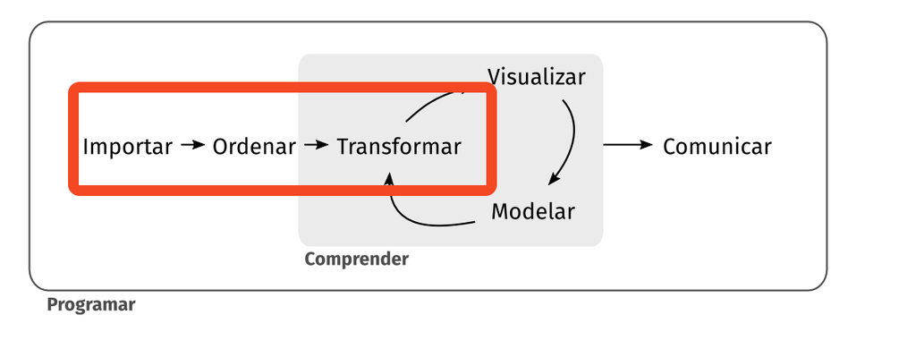

## Agrupar

La mayoría de las operaciones de datos se realizan en grupos definidos por variables. `group_by()` toma un tbl existente y lo convierte en un tbl agrupado donde las operaciones se realizan «por grupo». `ungroup()` elimina la agrupación.

## Agrupar por un Atributo

los datos se pueden agrupar según un criterio, por ejemplo, según el año o según el continente o alguna variable categórica que contenga el conjunto de datos

## Agrupar por más de un Atributo

También se pueden agrupar por diversos criterios, los cuales serán aplicados jerarquicamente según el orden de aparición de los criterios pudiendo llevar a resultados distintos.

## Reframe

Crea una nueva df aplicando funciones a las columnas de una df existente. También se usa `summarise`, pero es recomendable usar esta función que es más reciente

Existe pérdida de estructura de datos original así que es recomendable no reasignar la variable

Se puede hacer en algunos casos el `ungroup` para desagrupar

Los factores son útiles porque permiten a las funciones estadísticas tratar estos tipos de datos de manera más eficiente.